# Topic 3

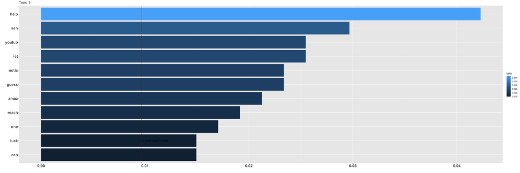

On interpreting beta: the term has a beta probability of being generated from the particular topic.

Values below are gamma : An estimated proportion of words from that document that are generated from that topic.

**Text Record Number: 631** gamma: 9 % likelihood of this document (based on its words) in this topic

**I’m doing something similar with a piece. I realised it’s beyond my scope at the moment but, rather than drop it, I mixed in other simpler pieces so I can always ‘feel’ progress.**

**Text Record Number: 1203** gamma: 9 % likelihood of this document (based on its words) in this topic

**I’m coming from a similar place and I think it’s definitely worth it.

I spent some months copying Youtube tutorials and only recently hired a piano teacher. Learning the basics about intervals and chords just lets you see music in a different way. Revisiting old songs with what I know now was almost like a eureka moment.

Good luck :)**

**Text Record Number: 4** gamma: 9 % likelihood of this document (based on its words) in this topic

**I’m sure its good, but another resource you can look into is Bartok’s mikrokosmos. I am using it and it is absolutely fantastic, its amazing how fast it helps you. I’m not saying its better or worse, but Bartok’s is a great resource for beginners, imo.**

**Text Record Number: 1292** gamma: 9 % likelihood of this document (based on its words) in this topic

**So I’ve pretty much gotten my scales down and I understand the 7 chords that can come out of each scale. I’m interested in learning more about when you can play keys out of scale and how and when to pick the right ones while keeping the harmony. Does anyone know of any good YouTube tutorials for this subject?**

**Text Record Number: 1326** gamma: 9 % likelihood of this document (based on its words) in this topic

**Hi! I wanna learn some new songs, and i thought youtube could be an interesting source of tutorials.

But i found out most tutorials for rock and pop music use a Synthesia style method, while i want to be able to read and play music, not just memorize the song.  
Also, most arrangements also play the melody, while i want to sing it.

Can you recommend some channels?**

**Text Record Number: 581** gamma: 9 % likelihood of this document (based on its words) in this topic

**I’ve been learning for 2-3 months now. I bought a few books but the one that helped me at first was kids book, playing nursery rhymes! One of the books I bought I have found pretty useless because it was theory and practise drills and zero fun!

The next book I have is Easy Piano songs for beginners which I am working my way through

I’ve been learning for 2-3 months now. I bought a few books but the one that helped me at first was a kids book, playing nursery rhymes! One of the books I bought I have found pretty useless because it was theory and practise drills and zero fun!

I can play Amazing Grace, Let it Be, Silent Night, All Things Bright and Beautiful and some others so far

I get a sense of achievement and satisfaction once I can play a song without errors

Maybe not the most advanced method of learning but this is the way that has worked for me (so far). I don’t like being on a course I like t do my own thing so I buy a few books and find some songs that are not too difficult but not too easy and then try to advance like that**

**Text Record Number: 588** gamma: 9 % likelihood of this document (based on its words) in this topic

**Thanks for your reply!  
Maybe I should have described my current level a bit better and mention that I already play Op. 49 no.2, both movements. I’m still working to smoothen the part in the minuet where there are 16th notes in both hands, but otherwise it’s quite alright, as the teacher says. I also Play Mozart’s K.545 almost in the right tempo (allegretto-ish), and working to smoothen the scale runs in the right hand (the scale runs in the left hand in the recapitulation are somehow already smooth =O). I might learn the Op. 49 no. 1 anyway, as it is more or less the same level and I like it more than the no. 2…

Playing Haydn sounds like a great idea! Do you have any specific pieces that you find both beautiful and helpful for this case? I’d love to hear…

8+ yeas sounds a bit harsh, doesn’t it? I was kind of hoping that It might take me 4 to 5 years, given that it took me 2 years to reach my current level from complete zero. Anyway, I am focused mostly on the short term, I **love** learning the fantasy in D minor, it’s so much fun to play! And I’m excited by starting the op. 64 waltzes… So this is just a long term background thought, not something that I’m really focusing my attention on :)**